# Прогнозирование цены подержанного автомобиля

Валиулин Юрий, Елисеев Арсений БЛГ-172

17.04.2020

## Постановка задачи

В файле `kuiper.xlsx` содержатся данные о характеристиках и цене продажи порядка 800 легковых автомобилей. Данные представляют собой случайную выборку из базы данных Kelly’s Blue Book, сделанную в 2005 году. Все автомобили в наборе данных были в эксплуатации менее года и находятся в отличном состоянии.

**Описание переменных**

- Price: рекомендованная цена продажи (целевая переменная)
- Mileage: пробег автомобиля в милях
- Make: производитель (Saturn, Pontiac, Chevrolet и др.)
- Model: конкретная модель (Ion, Vibe, Cavalier и др.)
- Trim: тип модели (SE Sedan 4D, Quad Coupe 2D и др)
- Type: тип кузова (седан, купе и др)
- Cylinder: количество цилиндров двигателя
- Liter: объем двигателя
- Doors: количество дверей
- Cruise: есть ли круиз-контроль (1 = cruise)
- Sound: тип аудиосистемы (1 = upgraded)
- Leather: кожаные сидения(1 = leather)

**Требуется:** 1. С помощью разведочного анализа и построения модели множественной регрессии в R выявить, какие факторы и каким образом влияют на цену продажи автомобиля.

2. Исследовать качество и адекватность полученной вами модели. При необходимости, изменить модель или преобразовать данные так, чтобы проблемы были максимально устранены.
3. Сравните свои модели по показателю MAPE.
4. Найдите в таблице машины, цена которых существенно ниже рекомендованной вашей моделью (т.е. недооцененные машины).

По работе необходимо подготовить отчет в HTML-формате, подробно поясняющий ваши решения в процессе исследования данных, выбора факторов и построения модели, проверки ее адекватности.

## Загрузка необходимых для работы пакетов:

```r
library(readr) # считывание данных из текстовых файлов
library(tidyverse) # манипулирование данными
```

```r
library(ggplot2) # визуализация
library(ggfortify) # визуализация диагностических графиков
library(modelr) # вспомогательные функции для работы с моделями
library(broom) # преобразование результатов моделирования в табличный вид
library(GGally) # построение матрицы диаграмм рассеяния
library(forcats) # работа с факторами
library(tidyr)
library(car)
```

## Загрузка данных об авто:

```r
library(readxl)
car <- read_excel("C:/Users/Юра/Desktop/KP-NIS-R/multiple regrestion/kuiper.xlsx")
View(car)
```

## Разведочный анализ:

```r
summary(car)
```

```
##      Price          Mileage          Make              Model               Trim
##  Min.   : 8639   Min.   :  266   Length:804         Length:804         Length:804
##  1st Qu.:14273   1st Qu.:14624   Class :character   Class :character   Class :character
##  Median :18025   Median :20914   Mode  :character   Mode  :character   Mode  :character
##  Mean   :21343   Mean   :19832
##  3rd Qu.:26717   3rd Qu.:25213
##  Max.   :70755   Max.   :50387
##      Type              Cylinder        Liter          Doors          Cruise          Sound
##  Length:804         Min.   :4.00   Min.   :1.60   Min.   :2.00   Min.   :0.000   Min.   :0.000
##  Class :character   1st Qu.:4.00   1st Qu.:2.20   1st Qu.:4.00   1st Qu.:1.000   1st Qu.:0.000
##  Mode  :character   Median :6.00   Median :2.80   Median :4.00   Median :1.000   Median :1.000
##                     Mean   :5.27   Mean   :3.04   Mean   :3.53   Mean   :0.752   Mean   :0.679
##                     3rd Qu.:6.00   3rd Qu.:3.80   3rd Qu.:4.00   3rd Qu.:1.000   3rd Qu.:1.000
##                     Max.   :8.00   Max.   :6.00   Max.   :4.00   Max.   :1.000   Max.   :1.000
##     Leather
##  Min.   :0.000
##  1st Qu.:0.000
##  Median :1.000
##  Mean   :0.724
##  3rd Qu.:1.000
##  Max.   :1.000
```

Для определения влияния переменных друг на друга, построим матрицу корреляции, для начала исключим из наблюдений качественные переменные, которые невозможно адекватно сравнивать с численными, которые составляют большинство в этих данных.

```r
cars_num <- car %>% select_if(is.numeric)

# Коэффициенты корреляции и их значимость
Hmisc::rcorr(as.matrix(cars_num))
```

```
##          Price Mileage Cylinder Liter Doors Cruise Sound Leather
## Price     1.00   -0.14     0.57  0.56 -0.14   0.43 -0.12    0.16
## Mileage  -0.14    1.00    -0.03 -0.02 -0.02   0.03 -0.03    0.00
## Cylinder  0.57   -0.03     1.00  0.96  0.00   0.35 -0.09    0.08
## Liter     0.56   -0.02     0.96  1.00 -0.08   0.38 -0.07    0.09
## Doors    -0.14   -0.02     0.00 -0.08  1.00  -0.05 -0.06   -0.06
## Cruise    0.43    0.03     0.35  0.38 -0.05   1.00 -0.09   -0.07
## Sound    -0.12   -0.03    -0.09 -0.07 -0.06  -0.09  1.00    0.17
## Leather   0.16    0.00     0.08  0.09 -0.06  -0.07  0.17    1.00
##
## n= 804
##
##
## P
##          Price  Mileage Cylinder Liter  Doors  Cruise Sound  Leather
## Price           0.0000  0.0000   0.0000 0.0000 0.0000 0.0004 0.0000
## Mileage  0.0000         0.4041   0.5977 0.6314 0.4784 0.4591 0.9773
## Cylinder 0.0000 0.4041           0.0000 0.9502 0.0000 0.0109 0.0323
## Liter    0.0000 0.5977  0.0000          0.0246 0.0000 0.0633 0.0132
## Doors    0.0000 0.6314  0.9502   0.0246        0.1769 0.0764 0.0791
## Cruise   0.0000 0.4784  0.0000   0.0000 0.1769        0.0093 0.0454
## Sound    0.0004 0.4591  0.0109   0.0633 0.0764 0.0093        0.0000
## Leather  0.0000 0.9773  0.0323   0.0132 0.0791 0.0454 0.0000
```

**Построение диаграмм рассеивания и коэффициентов корреляции:**

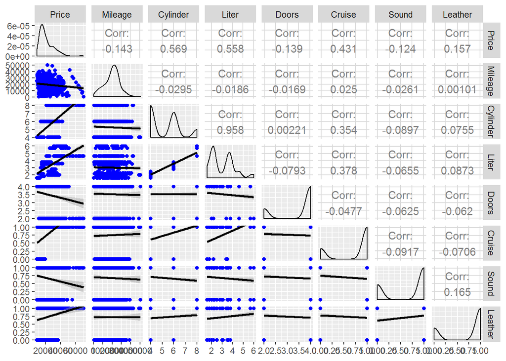

*Вывод:* На диаграммах рассеяния видна зависимость между всеми переменными и ценой. Коэффициенты корреляции ненулевые и статистически значимы.

Для большого количества переменных матрица диаграмм рассеяния получается слишком громоздкой. Лучше исследовать связь каждой переменной с целевой в отдельности. Для этого придется преобразовать данные в “длинный” формат.

**Преобразование данных:** Оставляем только количественные переменные:

```r
cars_tall <- car %>%
  gather(key = 'Показатель', value = 'Значение', Mileage:Leather, -Make, -Model, -Trim, -Type)
```

## Построение регрессионных диаграмм:

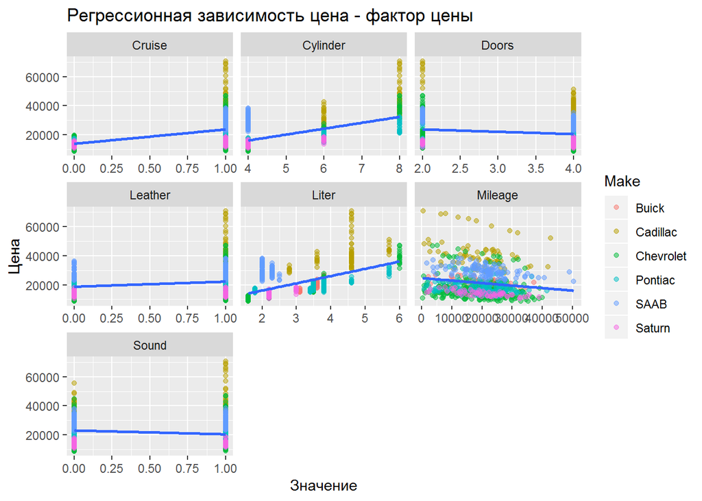

```r
ggplot(data = cars_tall,
       mapping = aes(x = `Значение`, y = Price)) +
  geom_point( aes( color = Make),alpha = 0.5) +
  stat_smooth(method = lm, se = F) +
  facet_wrap(~ `Показатель`, scale = 'free_x')+
  labs(title = 'Регрессионная зависимость цена - фактор цены', x = 'Значение', y = 'Цена')
```

Этот вывод не окончательный, а промежуточный. Дольнейшие исследования будут направлены на подтверждение или опровержение гипотез!

**В данной таблице лучше видны коэффициенты корреляции:**

```r
cars_tall %>%
  group_by(`Показатель`) %>%
  summarise(r = cor(Price, `Значение`)) %>%
  arrange(desc(abs(r)))
```

```
## # A tibble: 7 x 2
##   Показатель      r
##   <chr>       <dbl>
## 1 Cylinder    0.569
## 2 Liter       0.558
## 3 Cruise      0.431
## 4 Leather     0.157
## 5 Mileage    -0.143
## 6 Doors      -0.139
## 7 Sound      -0.124
```

**Построим модель простой линейной регрессии по переменной Количество цилиндров, т.к. коффициент ее корреляции наибольший:**

```r
cyl <- lm(Price ~ Cylinder, data = car)
summary(cyl)
```

```
##
## Call:
## lm(formula = Price ~ Cylinder, data = car)
##
## Residuals:
##    Min     1Q Median     3Q    Max
## -11216  -5230  -2749   2773  38339
##
## Coefficients:
##             Estimate Std. Error t value Pr(>|t|)
## (Intercept)    -17.1     1126.9   -0.02     0.99
## Cylinder      4054.2      206.9   19.60   <2e-16 ***
## ---
## Signif. codes:  0 '***' 0.001 '**' 0.01 '*' 0.05 '.' 0.1 ' ' 1
##
## Residual standard error: 8130 on 802 degrees of freedom
## Multiple R-squared:  0.324,  Adjusted R-squared:  0.323
## F-statistic:  384 on 1 and 802 DF,  p-value: <2e-16
```

Прогноз:

```r
cyl5 <-
  car %>%
  add_predictions(cyl, var = "Predicted") %>%
  select(Price, Predicted)
```

*Вывод:* Получилась линейная модель:

Цена = 4054*Количество цилиндров-17.1

Цена автомобиля возрастрает примерно на 4000 при увеличении количества цилиндров на 1.

**Построим график прогноза регресимонной модели Цена-Число циллиндров:**

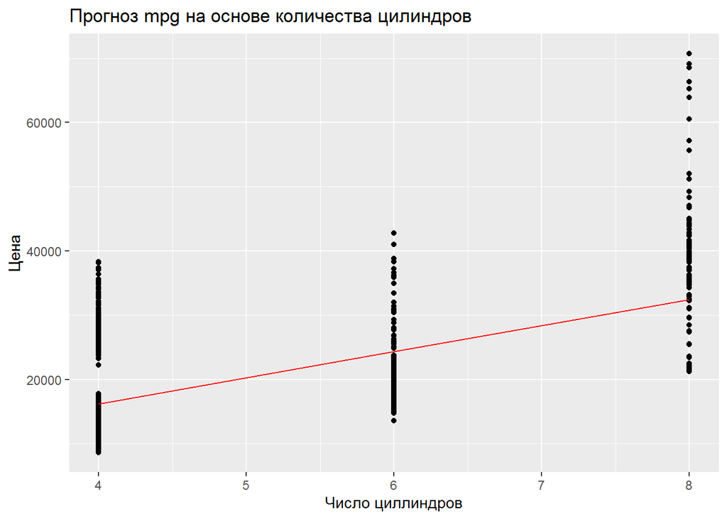

```r
ggplot(add_predictions(car, cyl, var = 'fit')) +
  geom_point(aes(Cylinder, Price)) +
  geom_line(aes(Cylinder, fit), colour = 'red') +
  labs(title = 'Прогноз mpg на основе количества цилиндров', y="Цена", x="Число циллиндров")
```

**Проверка точности модели:**

```r
glance(cyl) %>% select(r.squared, sigma) # эта же информация есть и в summary()
```

```
## # A tibble: 1 x 2
##   r.squared sigma
##       <dbl> <dbl>
## 1     0.324 8133.
```

**Вывод:** Модель объяснила 32% дисперсии исходных данных, ее стандартная ошибка равна 8133 доллара на цилиндр.Это достатоно плохие показатели для модели.Возможно стоит рассмотреть несколько факторов для построения модели, более точно предсказывающей значения.

**Оставшиеся переменнные:**

```r
car %>%
  add_residuals(cyl, var = "residual") %>% #добавили остатки
  select_if(is.numeric) %>% # убрали текстовые столбцы
  select(-Cylinder, -Price) %>% #убрали уже учтенные в модели переменные
  gather('var', 'value', Mileage:Leather) %>% #длинный формат данных
  group_by(var) %>% # сгруппировали по названию переменной
  summarise(r = cor(value, residual)) %>% # посчитали коэффициент корреляции для каждой группы
  arrange(desc(abs(r)))
```

```
## # A tibble: 6 x 2
##   var           r
##   <chr>     <dbl>
## 1 Cruise   0.279
## 2 Doors   -0.170
## 3 Mileage -0.154
## 4 Leather  0.139
## 5 Sound   -0.0891
## 6 Liter    0.0158
```

**Модель множественной регрессии кол-во цилиндров-салон:**

```r
cyll <- lm(Price ~ Cylinder +  Leather, data = car)
summary(cyll)
```

```
##
## Call:
## lm(formula = Price ~ Cylinder + Leather, data = car)
##
## Residuals:
##    Min     1Q Median     3Q    Max
## -11748  -5318  -2838   3078  37807
##
## Coefficients:
##             Estimate Std. Error t value Pr(>|t|)
## (Intercept)    -1529       1179   -1.30      0.2
## Cylinder        3992        206   19.42  < 2e-16 ***
## Leather         2538        638    3.98  7.5e-05 ***
## ---
## Signif. codes:  0 '***' 0.001 '**' 0.01 '*' 0.05 '.' 0.1 ' ' 1
##
## Residual standard error: 8060 on 801 degrees of freedom
## Multiple R-squared:  0.337,  Adjusted R-squared:  0.335
## F-statistic:  204 on 2 and 801 DF,  p-value: <2e-16
```

Прогноз:

```r
cylsal <-
  car %>%
  add_predictions(cyll, var = "Predicted") %>%
  select(Price, Predicted)
```

*Вывод:*

Цена=-1529+3992 * количество цилиндров + 2538 * салон

Среди автомобилей с одинаковым количеством цилиндров, наличие кожаного салона увеличивает ее стоимость на 2538 долларов

Среди автомобилей с одинаковым салоном, увеличение на 1 цилиндр в двигателе увеличивает стоимость авто на 3992 доллара.

**Проноз: авто с 4 цилиндрами и некожаным салоном:**

```r
newcar <- tibble(Cylinder = 4, Leather = 0)
predict(cyll, newcar, interval = 'prediction', level = 0.9 )
```

```
##     fit  lwr   upr
## 1 14441 1135 27747
```

**Визуализация:**

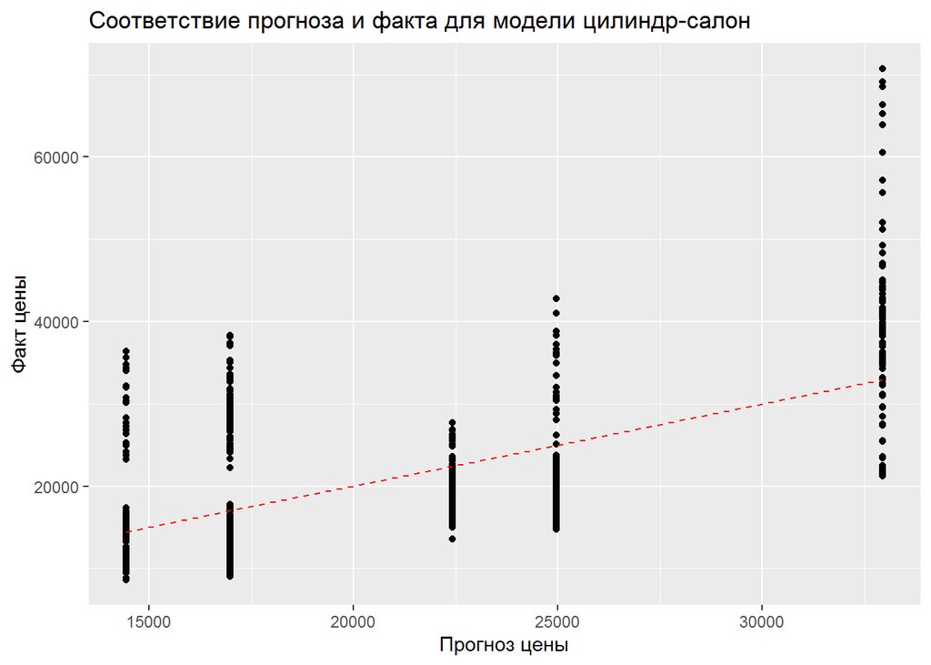

```r
ggplot(add_predictions(car, cyll, var = 'fit'),
       aes(fit, Price)) +
  geom_point() +
  geom_line(aes(fit, fit), color = 'red', linetype = 'dashed') +
  labs(title = 'Соответствие прогноза и факта для модели цилиндр-салон',
       x = 'Прогноз цены',
       y = 'Факт цены')
```

**Вывод:**В идеальном случае должна быть получена прямая линия, как видно прогноз неидеален, что подтверждается на графиках рассеяния:

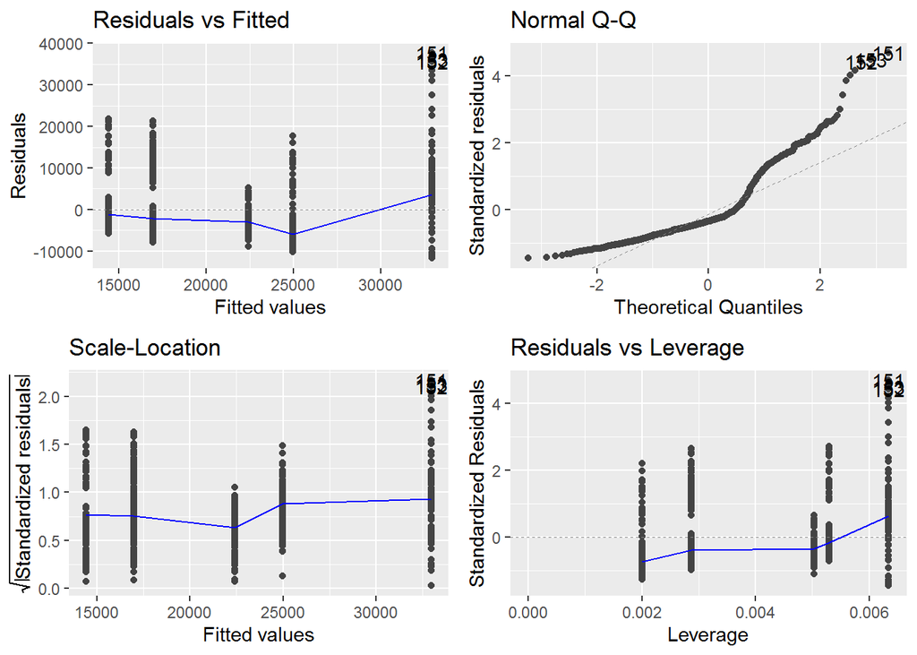

```r
autoplot(cyll)
```

```r
glance(cyll) %>% select(r.squared, sigma) # эта же информация есть и в summary()
```

```
## # A tibble: 1 x 2
##   r.squared sigma
##       <dbl> <dbl>
## 1     0.337 8059.
```

Модель объяснила 33% дисперсии исходных данных, ее стандартная ошибка равна 8059 доллара на цилиндр.Это достатоно плохие показатели для модели, тем не менее, они незначительно лучше, чем у модели цена-цилиндр

Попробуем воспользоваться нелинейными методами регрессионного анализа:

**Используем квадратичную зависимость:**

```r
cyll_square <- lm(Price ~ Cylinder+I(Cylinder^2) + Leather+I(Leather^2), data = car)
summary(cyll_square)
```

```
##
## Call:
## lm(formula = Price ~ Cylinder + I(Cylinder^2) + Leather + I(Leather^2),
##     data = car)
##
## Residuals:
##    Min     1Q Median     3Q    Max
## -17767  -4611  -2307   2405  31787
##
## Coefficients: (1 not defined because of singularities)
##               Estimate Std. Error t value Pr(>|t|)
## (Intercept)      62435       4781   13.06   <2e-16 ***
## Cylinder        -19447       1718  -11.32   <2e-16 ***
## I(Cylinder^2)     2058        150   13.72   <2e-16 ***
## Leather            378        595    0.64     0.53
## I(Leather^2)        NA         NA      NA       NA
## ---
## Signif. codes:  0 '***' 0.001 '**' 0.01 '*' 0.05 '.' 0.1 ' ' 1
##
## Residual standard error: 7260 on 800 degrees of freedom
## Multiple R-squared:  0.463,  Adjusted R-squared:  0.461
## F-statistic:  230 on 3 and 800 DF,  p-value: <2e-16
```

Прогноз:

```r
cylsal2 <-
  car %>%
  add_predictions(cyll_square, var = "Predicted") %>%
  select(Price, Predicted)
```

Графики рассеяния:

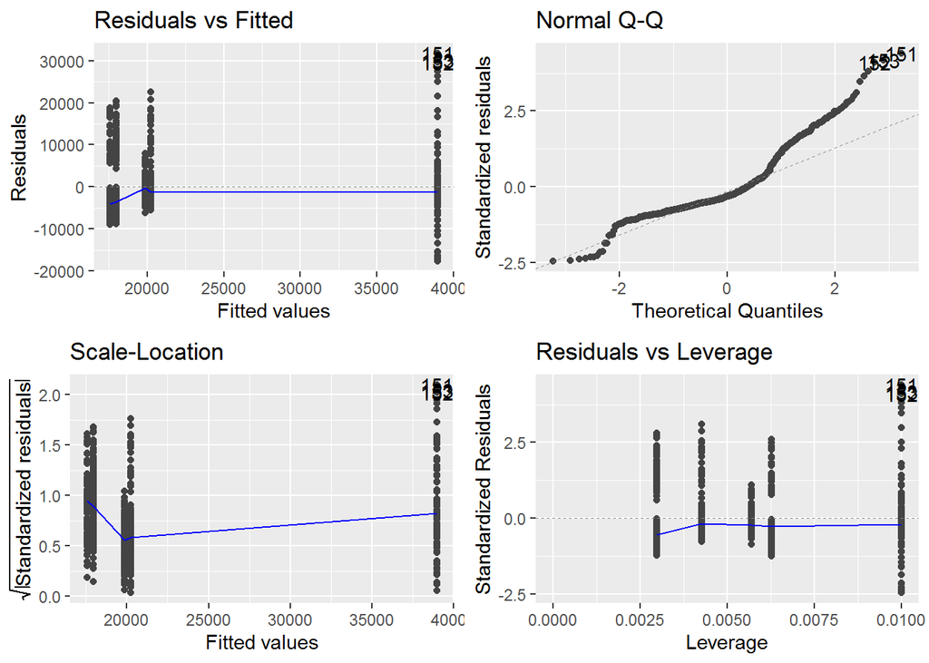

```r
autoplot(cyll_square)
```

Первичная проверка точности модели:

```r
glance(cyll_square) %>% select(r.squared, sigma) # эта же информация есть и в summary()
```

```
## # A tibble: 1 x 2
##   r.squared sigma
##       <dbl> <dbl>
## 1     0.463 7255.
```

**Вывод** Модель также показала плохие результаты. Попробуем использовать другие переменные. Для этого, определим связи переменных с ценой:

Сначала разделим автомобили по производителю, т.к. разные марки по разному ассоциируются в газах покупателей, что может завышать или занижать цену авто.

```r
cars2f <- car %>%
  mutate(Make = factor(Make, levels = c('Cadillac', 'Buick', 'Pontiac', 'Saturn', 'SAAB', 'Chevrolet')))
```

Посмотрим как связаны переменные: литры-цена

```r
lm(Price ~ Liter * Make, data = cars2f)
```

```
##
## Call:
## lm(formula = Price ~ Liter * Make, data = cars2f)
##
## Coefficients:
##         (Intercept)                Liter            MakeBuick          MakePontiac
##               17723                 5291               -27422                -9218
##          MakeSaturn             MakeSAAB        MakeChevrolet      Liter:MakeBuick
##              -12747                20588               -17063                 3041
##   Liter:MakePontiac     Liter:MakeSaturn       Liter:MakeSAAB  Liter:MakeChevrolet
##               -2289                -1433                -9393                  205
```

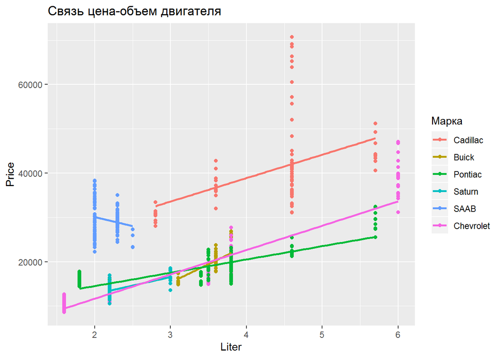

```r
ggplot(cars2f, aes(Liter, Price, colour = Make)) +
  geom_point() +
  geom_smooth(method = lm, se = F) +
  labs(title = "Связь цена-объем двигателя",
     colour = "Марка")
```

Обычно с ростом литров двигателя растет и цена, исключая СААБ. Также, легко заметить, что наклоны прямых дял разных марок разные, следовательно , возможно необходимо прогнозировать для каждой отдельной марки.

Переменные цена-салон

```r
lm(Price ~ Leather * Make, data = cars2f)
```

```
##
## Call:
## lm(formula = Price ~ Leather * Make, data = cars2f)
##
## Coefficients:
##           (Intercept)                Leather              MakeBuick            MakePontiac
##                 39932                   1004                 -19099                 -22356
##            MakeSaturn               MakeSAAB          MakeChevrolet      Leather:MakeBuick
##                -26032                 -10579                 -24317                  -1045
##   Leather:MakePontiac     Leather:MakeSaturn       Leather:MakeSAAB  Leather:MakeChevrolet
##                   301                   -842                   -809                     NA
```

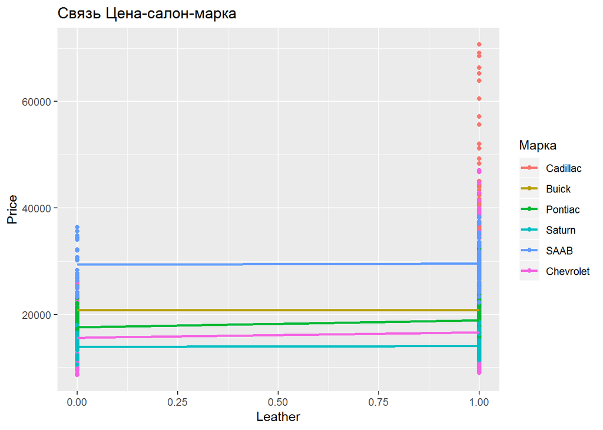

```r
ggplot(cars2f, aes(Leather, Price, colour = Make)) +
  geom_point() +
  geom_smooth(method = lm, se = F) +
  labs(title = "Связь Цена-салон-марка",
     colour = "Марка")
```

Видно, что регрессионные прямые не имеют наклона (практически), так что можно предположить, что салон не влияет на окончательную цену авто, в развере авто на марки. Переменные: круиз-цена

```r
lm(Price ~ Cruise * Make, data = cars2f)
```

```
##
## Call:
## lm(formula = Price ~ Cruise * Make, data = cars2f)
##
## Coefficients:
##          (Intercept)                Cruise             MakeBuick           MakePontiac
##                36438                  4498                -20121                -21282
##           MakeSaturn              MakeSAAB         MakeChevrolet      Cruise:MakeBuick
##               -23199                -11442                -22695                    NA
##   Cruise:MakePontiac     Cruise:MakeSaturn       Cruise:MakeSAAB  Cruise:MakeChevrolet
##                 -175                 -2855                    NA                    NA
```

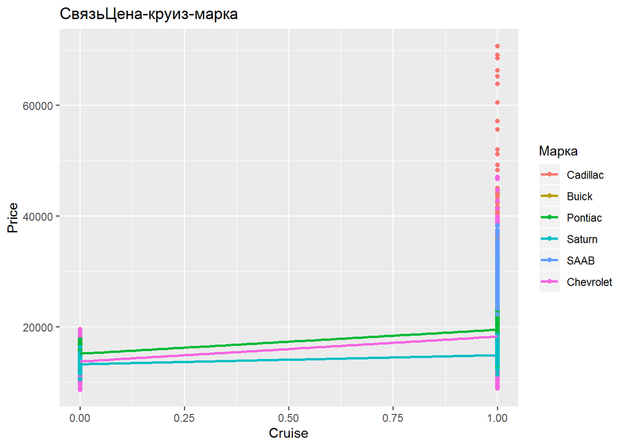

```r
ggplot(cars2f, aes(Cruise, Price, colour = Make)) +
  geom_point() +
  geom_smooth(method = lm, se = F) +
  labs(title = "СвязьЦена-круиз-марка",
     colour = "Марка")
```

Наличие круиз контроля в разрезе по маркам также не сильно влияет на окончательную цену (учитывая также и то, что не все авто имеют круиз)

Переменные: типа авто-пробег-цена

```r
cars2f10 <- car %>%
  mutate(Type = factor(Type, levels = c('Hatchback', 'Wagon', 'Sedan', 'Convertible', 'Coupe')))

lm(Price ~ Mileage * Make, data = cars2f10)
```

```
##
## Call:
## lm(formula = Price ~ Mileage * Make, data = cars2f10)
##
## Coefficients:
##           (Intercept)                Mileage           MakeCadillac          MakeChevrolet
##              2.40e+04              -1.56e-01               2.30e+04              -4.53e+03
##           MakePontiac               MakeSAAB             MakeSaturn   Mileage:MakeCadillac
##             -3.77e+03               9.88e+03              -6.91e+03              -1.63e-01
## Mileage:MakeChevrolet    Mileage:MakePontiac       Mileage:MakeSAAB     Mileage:MakeSaturn
##              9.18e-04               6.18e-02              -5.33e-02               2.94e-03
```

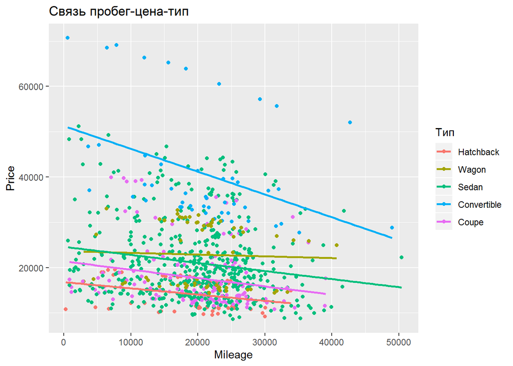

```r
ggplot(cars2f10, aes(Mileage, Price, colour = Type)) +
  geom_point() +
  geom_smooth(method = lm, se = F) +
  labs(title = "Связь пробег-цена-тип",
     colour = "Тип")
```

Основная тенженция состоит в уменьшении цены при увеличении пробега. Однако, дла авто разных типов наклон прямых сильно разнится. Возможно, стоит для каждого типа прогнозировать отдельно.

Переменные: цена-тип авто-литры

```r
cars2f10 <- car %>%
  mutate(Type = factor(Type, levels = c('Hatchback', 'Wagon', 'Sedan', 'Convertible', 'Coupe')))

lm(Price ~ Liter * Make, data = cars2f10)
```

```
##
## Call:
## lm(formula = Price ~ Liter * Make, data = cars2f10)
##
## Coefficients:
##         (Intercept)                Liter         MakeCadillac        MakeChevrolet
##               -9699                 8331                27422                10359
##         MakePontiac             MakeSAAB           MakeSaturn   Liter:MakeCadillac
##               18204                48010                14675                -3041
## Liter:MakeChevrolet    Liter:MakePontiac       Liter:MakeSAAB     Liter:MakeSaturn
##               -2835                -5329               -12434                -4473
```

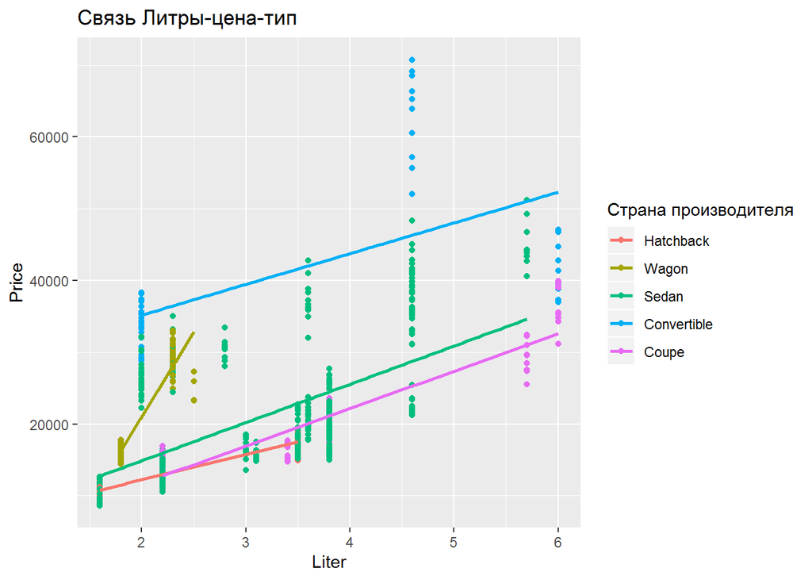

```r
ggplot(cars2f10, aes(Liter, Price, colour = Type)) +
  geom_point() +
  geom_smooth(method = lm, se = F) +
  labs(title = "Связь Литры-цена-тип",
     colour = "Страна производителя")
```

Основная тенденция общая - рост цены при росте литров двигателя. Однако, наклоны прямых для разных типов очень различны, что поти подтверждает предположение о прогнозе модели отдельно для каждого типа авто.

Переменные: двери-тип-цена

```r
cars2f10 <- car %>%
  mutate(Type = factor(Type, levels = c('Hatchback', 'Wagon', 'Sedan', 'Convertible', 'Coupe')))

lm(Price ~ Doors * Make, data = cars2f10)
```

```
##
## Call:
## lm(formula = Price ~ Doors * Make, data = cars2f10)
##
## Coefficients:
##         (Intercept)                Doors         MakeCadillac        MakeChevrolet
##               22119                 -326                65965                 3789
##         MakePontiac             MakeSAAB           MakeSaturn   Doors:MakeCadillac
##               -1671                16202                -7054               -12247
## Doors:MakeChevrolet    Doors:MakePontiac       Doors:MakeSAAB     Doors:MakeSaturn
##               -2483                 -240                -2215                   NA
```

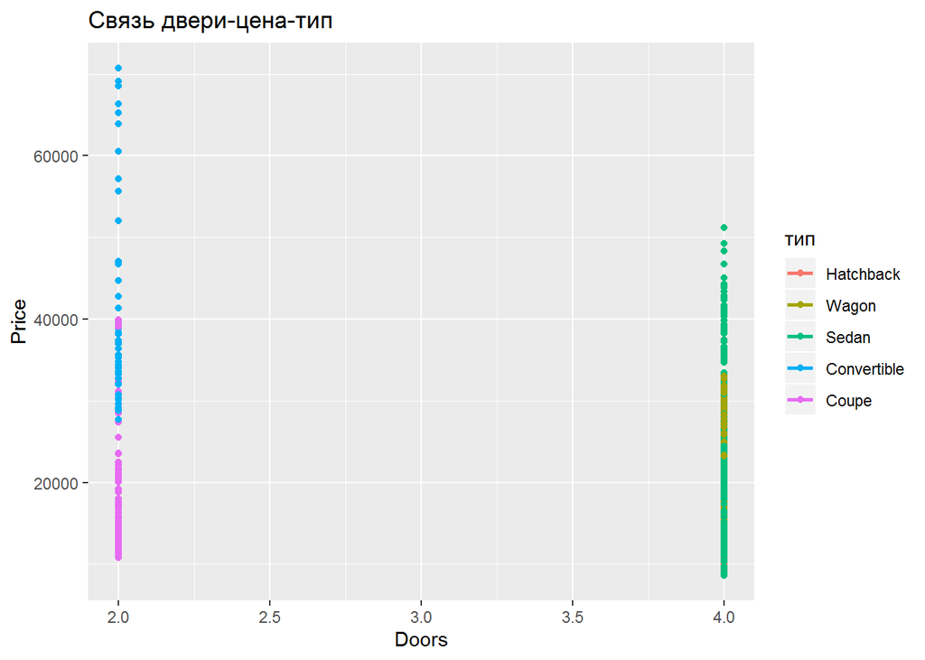

```r
ggplot(cars2f10, aes(Doors, Price, colour = Type)) +
  geom_point() +
  geom_smooth(method = lm, se = F) +
  labs(title = "Связь двери-цена-тип",
     colour = "тип")
```

**Примечание: было рассмотрено множесто вариантов моделей с несколькими переменными, в т.ч. квадратичные, с изменением Y. Так, как в дальнейшем выяснилась их неконкурентноспособность, было принято решение не добавлять их в конечную работу. Далее представлены намного более точные модели**

Попробуем применить полученные знания и использовать: типа авто, марка для разделения прогноза и прогнозирование отдельно для каждой марки или типа авто:

Построим модель: Цена-двери-Литры (двери прогнозируем отдельно по типу авто)

```r
qw <- lm(Price ~ Doors + Liter + Doors:Type, data = cars2f)

summary(qw)
```

```
##
## Call:
## lm(formula = Price ~ Doors + Liter + Doors:Type, data = cars2f)
##
## Residuals:
##    Min     1Q Median     3Q    Max
## -17573  -4042  -1459   1840  23374
##
## Coefficients: (1 not defined because of singularities)
##                     Estimate Std. Error t value Pr(>|t|)
## (Intercept)            35463       2147   16.52   <2e-16 ***
## Doors                  -5809        602   -9.66   <2e-16 ***
## Liter                   5117        208   24.58   <2e-16 ***
## Doors:TypeCoupe       -11118        513  -21.66   <2e-16 ***
## Doors:TypeHatchback    -2776        281   -9.88   <2e-16 ***
## Doors:TypeSedan        -1833        214   -8.55   <2e-16 ***
## Doors:TypeWagon           NA         NA      NA       NA
## ---
## Signif. codes:  0 '***' 0.001 '**' 0.01 '*' 0.05 '.' 0.1 ' ' 1
##
## Residual standard error: 6230 on 798 degrees of freedom
## Multiple R-squared:  0.606,  Adjusted R-squared:  0.603
## F-statistic:  245 on 5 and 798 DF,  p-value: <2e-16
```

Проверка точности модели (первичная)

```r
glance(qw) %>% select(r.squared, sigma) # эта же информация есть и в summary()
```

```
## # A tibble: 1 x 2
##   r.squared sigma
##       <dbl> <dbl>
## 1     0.606 6226.
```

```r
qw1 <- lm(Price ~ Cylinder+ Doors + Liter + Doors:Type, data = cars2f)

summary(qw1)
```

```
##
## Call:
## lm(formula = Price ~ Cylinder + Doors + Liter + Doors:Type, data = cars2f)
##
## Residuals:
##    Min     1Q Median     3Q    Max
## -14591  -3945   -903   1621  20303
##
## Coefficients: (1 not defined because of singularities)
##                     Estimate Std. Error t value Pr(>|t|)
## (Intercept)            29371       2319   12.66  < 2e-16 ***
## Cylinder                3586        581    6.17  1.1e-09 ***
## Doors                  -5625        589   -9.55  < 2e-16 ***
## Liter                    793        730    1.09     0.28
## Doors:TypeCoupe       -10665        507  -21.04  < 2e-16 ***
## Doors:TypeHatchback    -3162        282  -11.23  < 2e-16 ***
## Doors:TypeSedan        -1980        211   -9.38  < 2e-16 ***
## Doors:TypeWagon           NA         NA      NA       NA
## ---
## Signif. codes:  0 '***' 0.001 '**' 0.01 '*' 0.05 '.' 0.1 ' ' 1
##
## Residual standard error: 6090 on 797 degrees of freedom
## Multiple R-squared:  0.624,  Adjusted R-squared:  0.621
## F-statistic:  220 on 6 and 797 DF,  p-value: <2e-16
```

Прогноз:

```r
doolittype <-
  car %>%
  add_predictions(qw1, var = "Predicted") %>%
  select(Price, Predicted)
```

Расчет точности модели (первичный)

```r
glance(qw1) %>% select(r.squared, sigma) # эта же информация есть и в summary()
```

```
## # A tibble: 1 x 2
##   r.squared sigma
##       <dbl> <dbl>
## 1     0.624 6087.
```

Модель: цена-цилиндр-двери-литры (двери разделены по марке)

```r
qw11 <- lm(Price ~ Cylinder+ Doors + Liter + Doors:Make, data = cars2f)

summary(qw11)
```

```
##
## Call:
## lm(formula = Price ~ Cylinder + Doors + Liter + Doors:Make, data = cars2f)
##
## Residuals:
##    Min     1Q Median     3Q    Max
## -10174  -2884   -168   1994  32027
##
## Coefficients:
##                     Estimate Std. Error t value Pr(>|t|)
## (Intercept)             9818       1295    7.58  9.6e-14 ***
## Cylinder                2123        526    4.04  5.9e-05 ***
## Doors                   1252        274    4.57  5.6e-06 ***
## Liter                   2049        601    3.41  0.00069 ***
## Doors:MakeBuick        -3563        215  -16.60  < 2e-16 ***
## Doors:MakePontiac      -3887        202  -19.27  < 2e-16 ***
## Doors:MakeSaturn       -4058        269  -15.07  < 2e-16 ***
## Doors:MakeSAAB           417        257    1.62  0.10552
## Doors:MakeChevrolet    -4069        204  -19.98  < 2e-16 ***
## ---
## Signif. codes:  0 '***' 0.001 '**' 0.01 '*' 0.05 '.' 0.1 ' ' 1
##
## Residual standard error: 4660 on 795 degrees of freedom
## Multiple R-squared:  0.78,   Adjusted R-squared:  0.777
## F-statistic:  352 on 8 and 795 DF,  p-value: <2e-16
```

Расчет точности модели (первичный)

```r
glance(qw11) %>% select(r.squared, sigma) # эта же информация есть и в summary()
```

```
## # A tibble: 1 x 2
##   r.squared sigma
##       <dbl> <dbl>
## 1     0.780 4663.
```

**Вывод:** Модель объяснила 78% дисперсии исходных данных, ее стандартная ошибка равна 4663, точность растет, значит движение идет в правильном направлении. Посмотрим диагностически графики (на предмет нормальности модели с неплохой точностью)

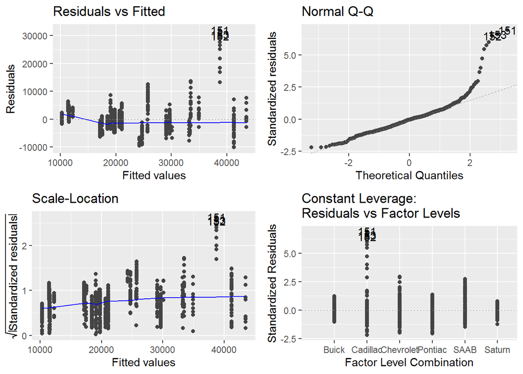

```r
autoplot(qw11)
```

Модель: цена-пробег-цилиндр-двери-литры (двери по маркам)

```r
qw111 <- lm(Price ~ Mileage + Cylinder+ Doors + Liter + Doors:Make, data = cars2f)

summary(qw111)
```

```
##
## Call:
## lm(formula = Price ~ Mileage + Cylinder + Doors + Liter + Doors:Make,
##     data = cars2f)
##
## Residuals:
##    Min     1Q Median     3Q    Max
## -10206  -2627   -253   1709  28714
##
## Coefficients:
##                      Estimate Std. Error t value Pr(>|t|)
## (Intercept)          1.35e+04   1.30e+03   10.41  < 2e-16 ***
## Mileage             -1.76e-01   1.91e-02   -9.19  < 2e-16 ***
## Cylinder             2.07e+03   5.00e+02    4.14  3.9e-05 ***
## Doors                1.20e+03   2.61e+02    4.60  5.0e-06 ***
## Liter                2.11e+03   5.72e+02    3.69  0.00024 ***
## Doors:MakeBuick     -3.50e+03   2.04e+02  -17.15  < 2e-16 ***
## Doors:MakePontiac   -3.88e+03   1.92e+02  -20.19  < 2e-16 ***
## Doors:MakeSaturn    -4.01e+03   2.56e+02  -15.65  < 2e-16 ***
## Doors:MakeSAAB       4.92e+02   2.45e+02    2.01  0.04467 *
## Doors:MakeChevrolet -4.05e+03   1.94e+02  -20.90  < 2e-16 ***
## ---
## Signif. codes:  0 '***' 0.001 '**' 0.01 '*' 0.05 '.' 0.1 ' ' 1
##
## Residual standard error: 4440 on 794 degrees of freedom
## Multiple R-squared:  0.801,  Adjusted R-squared:  0.799
## F-statistic:  355 on 9 and 794 DF,  p-value: <2e-16
```

Прогноз:

```r
pmcdl <-
  car %>%
  add_predictions(qw111, var = "Predicted") %>%
  select(Price, Predicted)
```

Проверка точности (первичная)

```r
glance(qw111) %>% select(r.squared, sigma) # эта же информация есть и в summary()
```

```
## # A tibble: 1 x 2
##   r.squared sigma
##       <dbl> <dbl>
## 1     0.801 4436.
```

**Вывод:** Модель объяснила 80% дисперсии исходных данных, ее стандартная ошибка равна 4436.

Попробуем модифицировать лучшую модель, изменив Y:

```r
t2 <- powerTransform(Price ~  Mileage + Cylinder+ Doors + Liter + Doors:Make, data = cars2f)
coef(t2)
```

```
##   Y1
## -0.4
```

Предлагают возвести Y в -0.4 степень. Для удобства, воведем в -0.5:

Модель: цена^-0.5-пробег-цилиндр-двери-литры (двери по маркам)

```r
qw0 <- lm(Price^-0.5 ~ Mileage + Cylinder+ Doors + Liter + Doors:Make, data = cars2f)
```

Прогноз:

```r
pmcdl1 <-
  car %>%
  add_predictions(qw0, var = "Predicted") %>%
  select(Price, Predicted) %>%
  mutate(Predicted = Predicted^(1/-0.5))
```

```r
qw0 <- lm(Price^-0.5 ~ Mileage + Cylinder^2+ Doors + Liter^2 + Doors:Make, data = cars2f)
```

Прогноз:

```r
pmcdl11 <-
  car %>%
  add_predictions(qw0, var = "Predicted") %>%
  select(Price, Predicted) %>%
  mutate(Predicted = Predicted^(1/-0.5))
```

Расчет ошибок представленных моделей:функция расчета ошибок

```r
errors <- function(actual, predicted) {
  error <- actual - predicted
  abs_error <- abs(actual - predicted)
  percent_error <- abs_error/actual

  ME <- mean(error, na.rm = T)
  MAE <- mean(abs_error, na.rm = T)
  MAPE <- mean(percent_error, na.rm = T)
  MSE <- mean(error^2, na.rm = T)
  RMSE <- sqrt(MSE)

  tibble(ME, MAE, MAPE, MSE, RMSE)
}
```

Расчет основных ошибок

```r
all_models <-
  bind_rows("Цилиндр" = cyl5,
          "цилиндр-салон" = cylsal,
          "Цилиндр2-салон2" = cylsal2,

          "двери-литер(тип)" = doolittype,
          "Пробег-цилиндр-двери-литер(марка)" = pmcdl,

          "Пробег-цилиндр-двери-литер(марка)-Y^-0.5" = pmcdl1,
          "Пробег-цилиндр2-двери-литер2(марка)-Y^-0.5"=pmcdl11,
          .id = "Model")

all_models %>%
  group_by(Model) %>%
  summarise(errors = list(errors(Price, Predicted))) %>%
  unnest() %>%
  arrange(MAPE) %>%
  knitr::kable()
```

| Model | ME | MAE | MAPE | MSE | RMSE |
| --- | --- | --- | --- | --- | --- |
| Пробег-цилиндр-двери-литер(марка)-Y^-0.5 | 280 | 2742 | 0.111 | 22507675 | 4744 |
| Пробег-цилиндр2-двери-литер2(марка)-Y^-0.5 | 280 | 2742 | 0.111 | 22507675 | 4744 |
| Пробег-цилиндр-двери-литер(марка) | 0 | 2963 | 0.144 | 19434459 | 4408 |
| двери-литер(тип) | 0 | 4483 | 0.207 | 36725809 | 6060 |
| Цилиндр2-салон2 | 0 | 5503 | 0.276 | 52375391 | 7237 |
| Цилиндр | 0 | 6288 | 0.298 | 65983775 | 8123 |
| цилиндр-салон | 0 | 6244 | 0.298 | 64703315 | 8044 |

Лучшая модель: Пробег-цилиндр-двери-литер(марка)-Y^-0.5 (квадратичная с аналогичными ошибками) Неудивительно, как и предполагалось, при выборе авто покупатели обычно смотрят на: пробег. объем двигателя (цилиндры и литры) и на вместимость (двери).

**Задание 4**

Соденим проноз лучше модели и найдем новый столбец “разность (diff)” для авто, чья цена была занижена в модели.

```r
car1 <- full_join(car, pmcdl1, by ='Price') %>%
  mutate ( diff= Price - Predicted)
```

График.

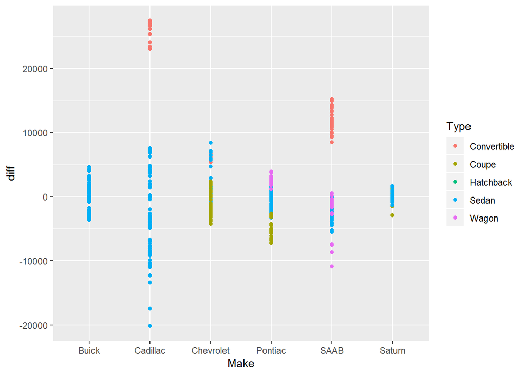

```r
ggplot(data = car1, mapping = aes(Make, diff)) +
  geom_point(aes(color = Type))
```